# Psych 251 PS5: Visualization

Jinxiao Zhang

12/2/2018

# Intro

```r
library(tidyverse)
library(ggthemes)
theme_set(theme_few())
sem <- function(x) {sd(x, na.rm=TRUE) / sqrt(sum(!is.na((x))))}
ci <- function(x) {sem(x) * 1.96} # reasonable approximation
```

This is problem set #4, in which we hope you will practice the visualization package `ggplot2`, as well as hone your knowledge of the packages `tidyr` and `dplyr`. You’ll look at two different datasets here.

First, data on children’s looking at social targets from Frank, Vul, Saxe (2011, Infancy).

Second, data from Sklar et al. (2012) on the unconscious processing of arithmetic stimuli.

In both of these cases, the goal is to poke around the data and make some plots to reveal the structure of the dataset.

# Part 1

This part is a warmup, it should be relatively straightforward `ggplot2` practice.

Load data from Frank, Vul, Saxe (2011, Infancy), a study in which we measured infants’ looking to hands in moving scenes. There were infants from 3 months all the way to about two years, and there were two movie conditions (`Faces_Medium`, in which kids played on a white background, and `Faces_Plus`, in which the backgrounds were more complex and the people in the videos were both kids and adults). An eye-tracker measured children’s attention to faces. This version of the dataset only gives two conditions and only shows the amount of looking at hands (other variables were measured as well).

```r
fvs <- read_csv("data/FVS2011-hands.csv")
```

First, use `ggplot` to plot a histogram of the ages of children in the study. NOTE: this is a repeated measures design, so you can’t just take a histogram of every measurement.

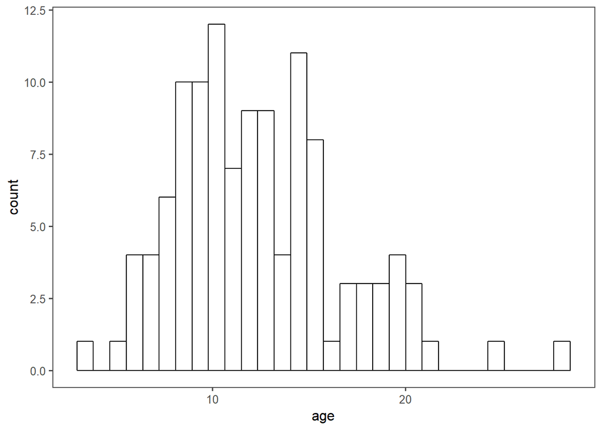

```r
ggplot(fvs %>% filter(condition == 'Faces_Medium'), aes(x=age)) + geom_histogram(color="black", fill="white")
```

Second, make a scatter plot showing the difference in hand looking by age and condition. Add appropriate smoothing lines. Take the time to fix the axis labels and make the plot look nice.

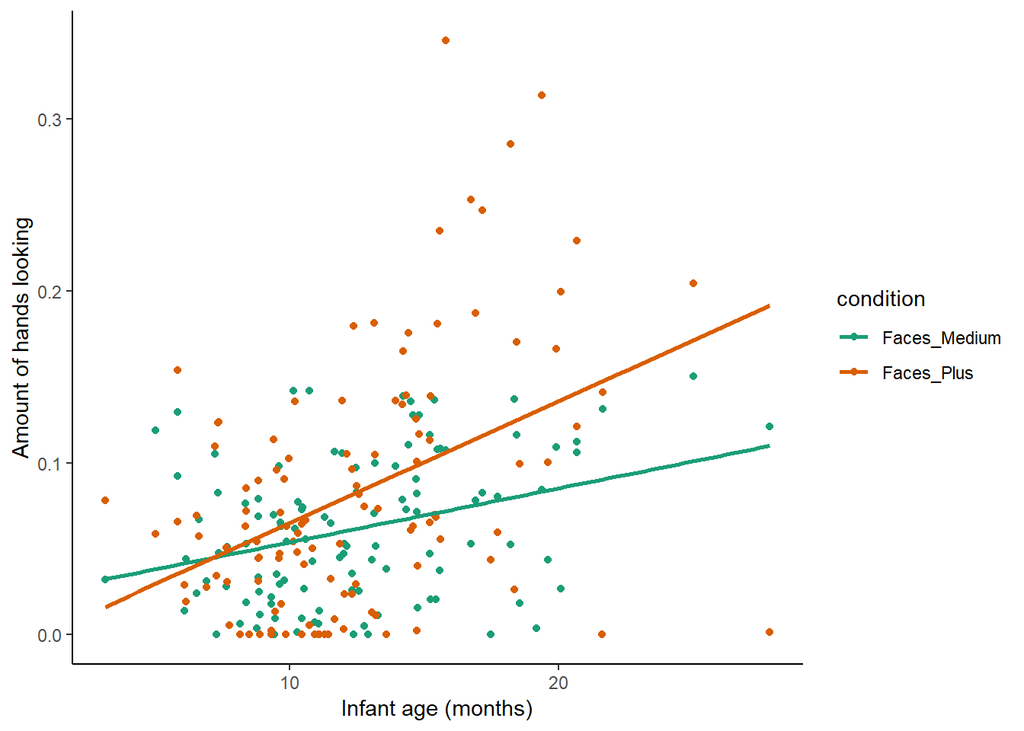

```r
ggplot(fvs, aes(x=age, y=hand.look, color=condition)) + geom_point()+
  geom_smooth(method=lm, se=FALSE, fullrange=TRUE)+
  theme_classic()+ scale_color_brewer(palette="Dark2")+
  labs(x="Infant age (months)", y = "Amount of hands looking")
```

What do you conclude from this pattern of data?

> It seems that as the infant’s age increases, the amount of hands looking increases faster in the Face Plus condition than the Face Medium condition.

What statistical analyses would you perform here to quantify these differences?

> A linear model with age*condition in prediction of hands looking.

# Part 2

Sklar et al. (2012) claim evidence for unconscious arithmetic processing - they prime participants with arithmetic problems and claim that the authors are faster to repeat the answers. We’re going to do a reanalysis of their Experiment 6, which is the primary piece of evidence for that claim. The data are generously shared by Asael Sklar. (You may recall these data from the `tidyverse` tutorial earlier in the quarter).

## Data Prep

First read in two data files and subject info. A and B refer to different trial order counterbalances.

```r
subinfo <- read_csv("data/sklar_expt6_subinfo_corrected.csv")
d_a <- read_csv("data/sklar_expt6a_corrected.csv")
d_b <- read_csv("data/sklar_expt6b_corrected.csv")
```

`gather` these datasets into long (“tidy data”) form. If you need to review tidying, [here’s the link to R4DS](http://r4ds.had.co.nz/tidy-data.html) (bookmark it!). Remember that you can use `select_helpers` to help in your `gather`ing.

Once you’ve tidied, bind all the data together. Check out `bind_rows`.

The resulting tidy dataset should look like this:

```
    prime prime.result target congruent operand distance counterbalance subid    rt
    <chr>        <int>  <int>     <chr>   <chr>    <int>          <int> <dbl> <int>
 1 =1+2+5            8      9        no       A       -1              1     1   597
 2 =1+3+5            9     11        no       A       -2              1     1   699
 3 =1+4+3            8     12        no       A       -4              1     1   700
 4 =1+6+3           10     12        no       A       -2              1     1   628
 5 =1+9+2           12     11        no       A        1              1     1   768
 6 =1+9+3           13     12        no       A        1              1     1   595
```

```r
a  <- d_a %>% gather(subid, rt, num_range('', 1:21))
b  <- d_b %>% gather(subid, rt, num_range('', 22:42))

d0 <- bind_rows(a,b)
```

Merge these with subject info. You will need to look into merge and its relatives, `left_` and `right_join`. Call this dataframe `d`, by convention.

```r
#make "subid" in d0 as integer (the subid in subinfo is in integer)
d0$subid <- as.numeric(d0$subid)

d <- left_join(d0, subinfo, by = "subid")
```

Clean up the factor structure (just to make life easier). No need to, but if you want, you can make this more `tidyverse`-ish.

```r
d$presentation.time <- factor(d$presentation.time)
levels(d$operand) <- c("addition","subtraction")
```

## Data Analysis Preliminaries

Examine the basic properties of the dataset. First, show a histogram of reaction times.

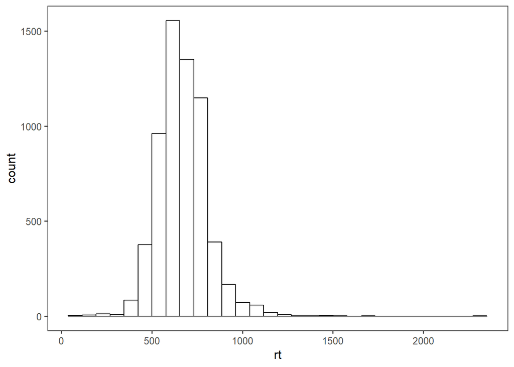

```r
ggplot(d0, aes(x=rt)) + geom_histogram(fill = "white", color = "black")
```

Challenge question: what is the sample rate of the input device they are using to gather RTs?

```r
rt <-  sort(unique(d$rt))

rt_diff = c()
for (i in 1:length(rt)-1){
  rt_diff <- append(rt_diff, rt[i+1] - rt[i])
}

rate = 1000/min(rt_diff)
```

> ANSWER HERE (OPTIONAL) The sampling rate is 1000 Hz because the smallest RT difference is 1.

Sklar et al. did two manipulation checks. Subjective - asking participants whether they saw the primes - and objective - asking them to report the parity of the primes (even or odd) to find out if they could actually read the primes when they tried. Examine both the unconscious and conscious manipulation checks. What do you see? Are they related to one another?

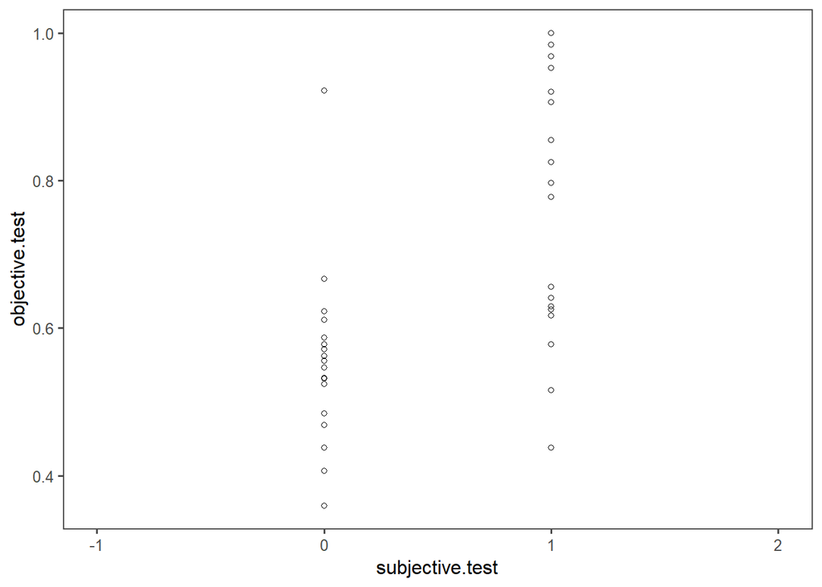

```r
ggplot(subinfo, aes(subjective.test, objective.test))+geom_point(shape = 1, color = "black", fill = "white")+xlim(-1, 2)
```

> Yes, those who did not consciously see the prime tended to have lower score in the objective test.

> In Experiments 6, 7, and 9, we used the binomial distribution to determine whether each participant performed better than chance on the block and excluded from analyses all those participants who did (21, 30, and 7 participants in Experiments 6, 7, and 9, respectively). Note that, although the number of excluded participants may seem high, they fall within the normal range of long-duration CFS priming, in which suc- cessful suppression is strongly affected by individual differences (38). We additionally excluded participants who reported any subjective awareness of the primes (four, five, and three participants in Experiments 6, 7, and 9, respectively).

OK, let’s turn back to the measure and implement Sklar et al.’s exclusion criterion. You need to have said you couldn’t see (subjective test) and also be not significantly above chance on the objective test (< .6 correct). Call your new data frame `ds`.

```r
ds <- d %>%
  filter(subjective.test == 0, objective.test < .6)
```

## Replicating Sklar et al.’s analysis

Sklar et al. show a plot of a “facilitation effect” - the amount faster you are for prime-congruent naming compared with prime-incongruent naming. They then show plot this difference score for the subtraction condition and for the two prime times they tested. Try to reproduce this analysis.

HINT: first take averages within subjects, then compute your error bars across participants, using the `ci` function (defined above). Sklar et al. use SEM (and do it incorectly, actually), but CI is more useful for “inference by eye” as discussed in class.

HINT 2: remember that in class, we reviewed the common need to `group_by` and `summarise` *twice*, the first time to get means for *each subject*, the second time to compute statistics *across subjects*.

HINT 3: The final summary dataset should have 4 rows and 5 columns (2 columns for the two conditions and 3 columns for the outcome: reaction time, ci, and n).

```r
summary <- ds %>%
  group_by(subid, congruent, operand, presentation.time) %>%
  summarise(rt_mean = mean(rt, na.rm = T)) %>%
  spread(congruent, rt_mean) %>%
  mutate(rt_diff = no - yes) %>%
  group_by(operand, presentation.time) %>%
  summarise(mean = mean(rt_diff), ci = ci(rt_diff), n = n())
```

Now plot this summary, giving more or less the bar plot that Sklar et al. gave (though I would keep operation as a variable here. Make sure you get some error bars on there (e.g. `geom_errorbar` or `geom_linerange`).

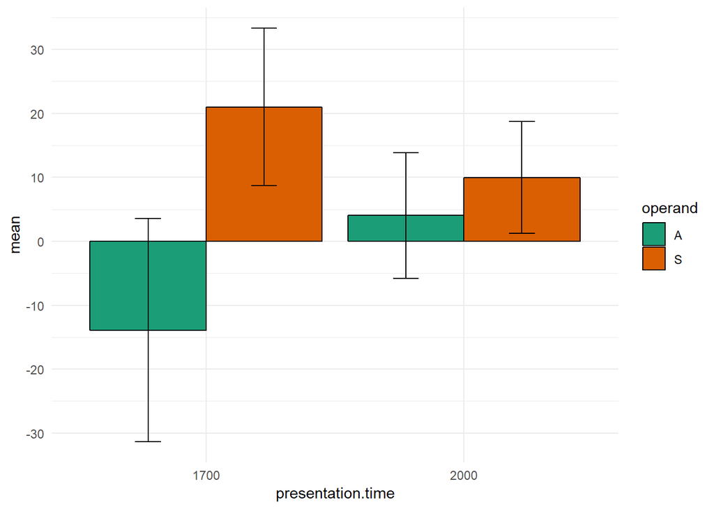

```r
ggplot(summary, aes(presentation.time, mean, fill = operand))+
  geom_bar(stat = "identity", position = position_dodge(), color = "black")+
  geom_errorbar(aes(ymin=mean - ci, ymax=mean + ci), width=.2,position=position_dodge(.9))+
  scale_y_continuous(breaks=seq(-30, 30, 10))+
  scale_fill_brewer(palette = "Dark2")+
  theme_minimal()
```

What do you see here? How close is it to what Sklar et al. report? How do you interpret these data?

> The facilitation effect was not significantly different between the two presentation times in either addition or subtraction condition (the error bars overlap). As compared with Sklar et al., the means of the bars are the same but the length of the error bars differ a lot. I will interprete that the facillitation effect was not different between the two prime conditions on presentation time. However, there seems a difference between addition and subtraction in the 1700 ms condition.